# rsibal_OriginalHomeworkCode_04

## [1] Write a simple R function, Z.prop.test(), that can perform one- or two-sample Z-tests for proportion data, using the following guidelines:

### Your function should take the following arguments: p1 and n1 (no default) representing the estimated proportion and sample size (i.e., based on your sample data); p2 and n2 (both defaulting to NULL) that contain a second sample’s proportion and sample size data in the event of a two-sample test; p0 (no default) as the expected value for the population proportion; and alternative (default “two.sided”) and conf.level (default 0.95), to be used in the same way as in the function t.test().

### When conducting a two-sample test, it should be p1 that is tested as being smaller or larger than p2 when alternative=“less” or alternative=“greater”, the same as in the use of x and y in the function t.test().

### The function should perform a one-sample Z-test using p1, n1, and p0 if either p2 or n2 (or both) is NULL.

### The function should contain a check for the rules of thumb we have talked about (n∗p>5 and n∗(1−p)>5) to ensure the validity of assuming the normal distribution in both the one- and two-sample settings. If this is violated, the function should still complete but it should also print an appropriate warning message.

### The function should return a list containing the members Z (the test statistic), P (the appropriate p value), and CI (the two-sided CI with respect to “conf.level” around p1 in the case of a one-sample test and around p2-p1 in the case of a two-sample test). For all test alternatives (“two.sided”, “greater”, “less”), calculate symmetric CIs based on quantiles of the normal distribution rather than worrying about calculating single-limit confidence bounds.

```r
Z.prop.test <- function(p1, n1, p2 = NULL, n2 = NULL, p0, alternative = "two.sided", conf.level = 0.95){

# if either p2 or n2 (or both) is NULL, perform one-sample Z-test using p1, n1, and p0.
test_type <- if(is.null(p2) | is.null(n2)) 1 else 2

# If assumption for normality is violated, the function should still complete but it should also print an appropriate warning message.
if (!(n1 * p0 > 5 & n1 * (1 - p0) > 5) |
      !(n2 * p0 > 5 & n2 * (1 - p0) > 5)) {
    print("ERROR: ASSUMPTION OF NORMAL DISTRIBUTION IS NOT VALID")
}

lambda<-1-(1-conf.level)/2

if(test_type == 1){
  z <- p1 - p0 / sqrt(p0(1-p0)/n1)
  if(alternative == "less"){
    p <- pnorm(z, lower.tail = TRUE)
  } else if(alternative == "greater"){
    p <- pnorm(z, lower.tail = FALSE)
  }
  lower <- p1 - qnorm(lambda) * sqrt(p1 * (1 - p1)/n1)
  upper <- p1 + qnorm(lambda) * sqrt(p1 * (1 - p1)/n1)
  ci <- c(lower, upper)
} else if (test_type == 2){
  z <- p2 - p1 / sqrt(p0*(1-p0)*(1/n1 + 1/n2))
  pVAL <- 1 - pnorm(z, lower.tail = TRUE) + pnorm(z, lower.tail = FALSE)
  ci_p = p2-p1
  #  Found this equation here: https://www.stats4stem.org/confidence-interval-two-proportions-difference-of-proportions#:~:text=For%202%20Proportions%2FDifference%20of,1%E2%88%92%5Ep2).
  lower <- ci_p - qnorm(lambda) * sqrt((p1 * (1 - p1))/n1 +  (p2 * (1 - p2))/n2)
  upper <- ci_p + qnorm(lambda) * sqrt((p1 * (1 - p1)/n1) +  (p2 * (1 - p2)/n2))
  ci <- c(lower, upper)
}

summary <- list(test_statistic=z,
                p_value=pVAL,
                confidence_interval=ci)
return(summary)
}
```

## [2] The dataset from Kamilar and Cooper has in it a large number of variables related to life history and body size. For this exercise, the end aim is to fit a simple linear regression model to predict longevity (MaxLongevity_m) measured in months from species’ brain size (Brain_Size_Species_Mean) measured in grams. Do the following for both longevity~brain size and log(longevity)~log(brain size):

### Fit the regression model and, using {ggplot2}, produce a scatterplot with the fitted line superimposed upon the data. Append the the fitted model equation to your plot (HINT: use the function geom_text()).

```r
library(curl)
```

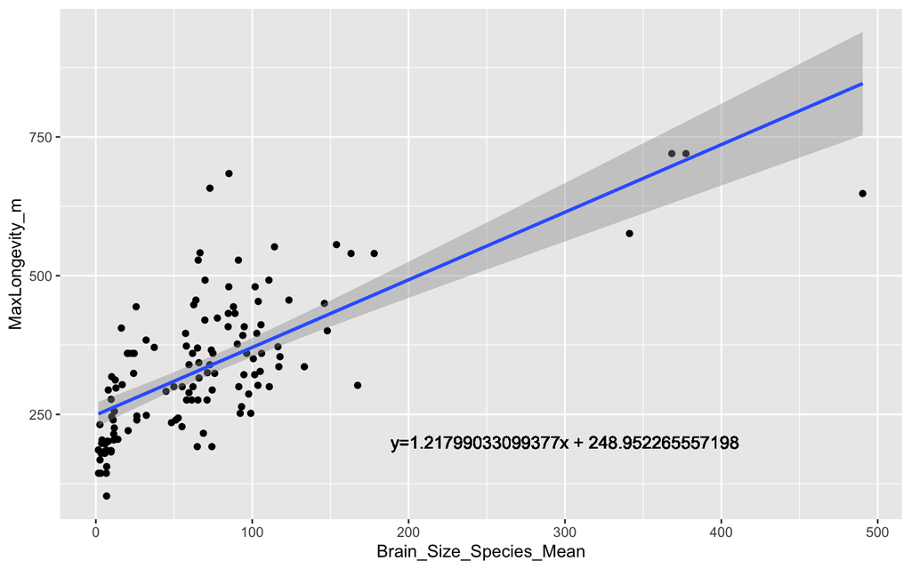

```r
library(ggplot2)
f <- curl("https://raw.githubusercontent.com/fuzzyatelin/fuzzyatelin.github.io/master/AN588_Fall23/KamilarAndCooperData.csv")
kandc_data <- read.csv(f, header = TRUE, sep = ",", stringsAsFactors = FALSE)

# We have to find the regression line separately first because geom_smooth doesn't give us the coefficients. From there we can make a string (rformula) representing the regression lines
rline_1<-lm(formula = MaxLongevity_m ~ Brain_Size_Species_Mean, data = kandc_data)
rformula<-paste0("y=", rline_1$coefficients[2],"x"," + ",rline_1$coefficients[1])
p1 <- ggplot(data = kandc_data, aes(x = Brain_Size_Species_Mean, y = MaxLongevity_m)) + geom_point() + geom_smooth(method = "lm", formula = y ~ x) + geom_text(x = 300, y = 200, label = rformula)

rline_2<-lm(formula = log(MaxLongevity_m) ~ log(Brain_Size_Species_Mean), data = kandc_data)
rformula<-paste0("y=", rline_2$coefficients[2],"x"," + ",rline_2$coefficients[1])
p2 <- ggplot(data = kandc_data, aes(x = log(Brain_Size_Species_Mean), y = log(MaxLongevity_m))) + geom_point() + geom_smooth(method = "lm", formula = y ~ x) + geom_text(x = 3, y = 4.8, label = rformula)

p1
```

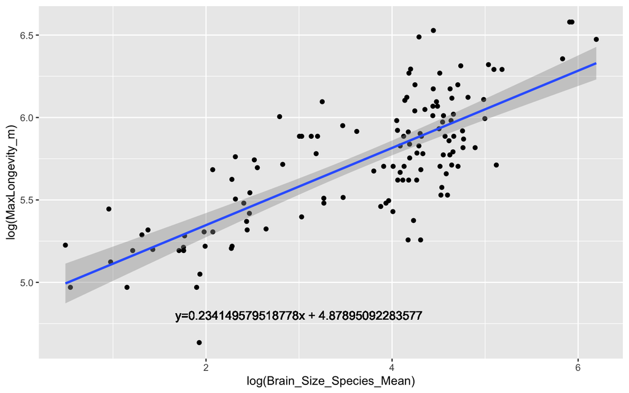

```r
p2
```

### Identify and interpret the point estimate of the slope (β1), as well as the outcome of the test associated with the hypotheses H0: β1 = 0; HA: β1 ≠ 0. Also, find a 90 percent CI for the slope (β1) parameter.

```r
# For the normal regressions
(beta1 = rline_1$coefficients[2])
```

```
## Brain_Size_Species_Mean
##                 1.21799
```

```r
t <- coef(summary(rline_1))
t <- data.frame(unlist(t))
lambda<-1-(1-0.90)/2

colnames(t) <- c("Est", "SE", "t", "p")
t$lower <- t$Est - qt(lambda, df = 998) * t$SE
t$upper <- t$Est + qt(lambda, df = 998) * t$SE
ci <- c(t$lower, t$upper)
(ci <- confint(rline_1, level = 0.90))  # using the results of lm())
```

```
##                                5 %      95 %
## (Intercept)             230.540738 267.36379
## Brain_Size_Species_Mean   1.035571   1.40041
```

```r
# For the log regression
(beta1_log = rline_2$coefficients[2])
```

```
## log(Brain_Size_Species_Mean)
##                    0.2341496
```

```r
t <- coef(summary(rline_2))
t <- data.frame(unlist(t))
colnames(t) <- c("Est", "SE", "t", "p")
t$lower <- t$Est - qt(lambda, df = 998) * t$SE
t$upper <- t$Est + qt(lambda, df = 998) * t$SE
ci_log <- c(t$lower, t$upper)
(ci_log <- confint(rline_2, level = 0.90))  # using the results of lm()
```

```
##                                    5 %      95 %
## (Intercept)                  4.7644934 4.9934084
## log(Brain_Size_Species_Mean) 0.2046396 0.2636595
```

```r
require(gridExtra)
```

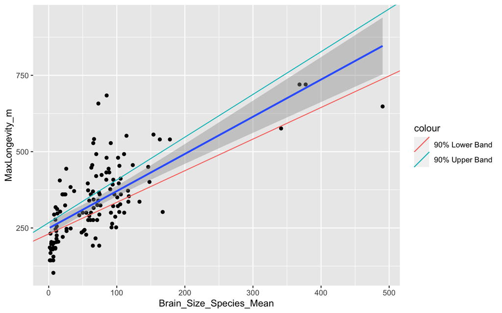

```r
p1 <- ggplot(data = kandc_data, aes(x = Brain_Size_Species_Mean, y = MaxLongevity_m)) + geom_point() + geom_smooth(method = "lm", formula = y ~ x) + geom_abline(aes(slope=ci[2], intercept=ci[1], color='90% Lower Band')) + geom_abline(aes(slope=ci[4], intercept=ci[3], color='90% Upper Band'))

p2 <- ggplot(data = kandc_data, aes(x = log(Brain_Size_Species_Mean), y = log(MaxLongevity_m))) + geom_point() + geom_smooth(method = "lm", formula = y ~ x) + geom_abline(aes(slope=ci_log[2], intercept=ci_log[1], color='90% Lower Band')) + geom_abline(aes(slope=ci_log[4], intercept=ci_log[3], color='90% Upper Band'))
p1
```

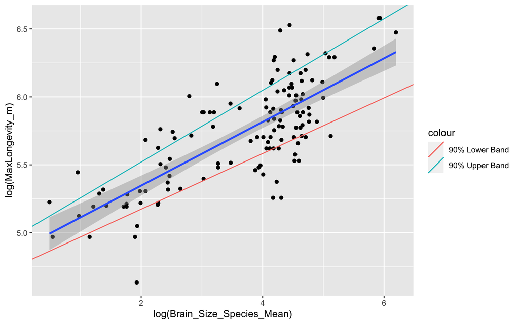

```r
p2
```

```r
# For normal values
predict(rline_1, newdata = data.frame(Brain_Size_Species_Mean = 800), interval = "confidence",
    level = 0.90)  # for a single value
```

```
##        fit      lwr      upr
## 1 1223.345 1089.461 1357.228
```

```r
# For log values
predict(rline_2, newdata = data.frame(Brain_Size_Species_Mean = 800), interval = "confidence",
    level = 0.90)  # for a single value
```

```
##       fit      lwr      upr
## 1 6.44415 6.348235 6.540065
```

### Looking at your two models, which do you think is better? Why?

Looking at our graphs, I think our log model does a better job at graphing the data. This is because by using log() we further normalize the data and can improve the linearity of the relationship.